# MATH70076: Data Science - Formative Assessment

MSc in Statistics 2026/27, Imperial College London

Author

02398379

**Deadline: Monday 12 October 2026 at 13:00.**

*For this formative assessment you should submit two files via the Imperial College VLE on Canvas by the deadline stated above. Your files should be named as follows:*

- `YOURCID-MATH70076-formative-assessment.pdf`: your rendered report,
- `YOURCID-MATH70076-formative-assessment.zip`: a zip file containing the relevant source code to generate your report.

*All submitted materials should be clearly presented and be understandable as stand-alone documents.*

*Please note that large files can take quite some time to upload. Ensure that you upload each document to the correct part of the learning space in a timely manner.*

*This mock coursework is a formative assessment and so will not contribute to your overall grade for the module. It is designed for you to practice the skills you have learned in the first workshop and to get feedback on your reflective writing style. This activity is expected to take approximately 6 hours of individual effort. Assessment criteria are given in the “set yourself up for success” boxes. Satisfying 18 or more out of these 23 criteria corresponds to a notional “pass” grade.*

*In submitting this mock assessment you certify that it is entirely your own work, apart from where otherwise acknowledged, and includes no plagiarism. Note that software tools are used as part of plagiarism detection.*

## Background

### Generalised Pareto Distribution

The Generalized Pareto Distribution (GPD) is a flexible family of continuous probability distributions that arises naturally in extreme value theory, particularly for modelling the distribution of excesses over a threshold. It is parametrised by a shape parameter $\xi \in \mathbb{R}$, a scale parameter $\sigma > 0$, and a location parameter $u \in \mathbb{R}$. Its cumulative distribution function (CDF) is given by

$$F(x;\,\sigma,\xi, u) =
\begin{cases}
1 - \left(1 + \dfrac{\xi (x-u)}{\sigma}\right)_+^{-1/\xi}, & \xi \neq 0, \, x \geq u; \; \\[1.2em]
1 - \exp\!\left(-\dfrac{x-u}{\sigma}\right), & \xi = 0, \, x \geq u;
\end{cases}
\tag{1}$$

where $x_+ = \max(x,0)$ and its probability density function (PDF) is

$$f(x;\sigma,\xi,u) =
\begin{cases}
\dfrac{1}{\sigma}\left(1 + \dfrac{\xi (x-u)}{\sigma}\right)_+^{-1/\xi - 1}, & \xi \neq 0, \\[1.2em]
\dfrac{1}{\sigma}\exp\!\left(-\dfrac{x-u}{\sigma}\right), & \xi = 0,
\end{cases}
\tag{2}$$

defined on the same support as the CDF. The GPD encompasses a variety of tail behaviours:

- when $\xi > 0$ the GPD has heavy, slowly decaying tails,
- in limiting case when $\xi \rightarrow 0$ the GPD reduces to an exponential distribution;
- when $\xi < 0$ the GPD has light, quickly decaying tails with a finite upper endpoint of $x^+ = u - \sigma / \xi$.

### Probability Integral Transform

The probability integral transform states that if a random variable $X$ has a continuous cumulative distribution function $F_X(x)$, then the transformed variable $A = F_X(X)$ follows a uniform distribution on $[0,1]$. Conversely, if $F$ is an invertible function then $Y = F^{-1}_X(A)$ has the same distribution as $X$.

## Questions

### Question 1

Derive an expression for the inverse cumulative distribution function (also known as the quantile function) $F^{-1}_X: [0,1] \rightarrow [u, x^+]$ of $X \sim \text{GPD}(u, \sigma, \xi)$. Your answer should refer to at least one equation given in the background material.

**TipSet yourself up for success**

Does your answer contain:

- a few sentences of text describing your approach to the problem;
- a reference to at least one equation from the background section;
- a correctly formatted LaTeX equation;
- a valid approach to the problem and correct expression.

Since $F_X$ from Equation 1 is continuous, then $A = F_X(X)$ with $A \sim U[0,1]$ by the probability integral transform. Therefore, let $p \in (0,1)$, the inverse CDF can be obtained by setting $p = F_X(x)$, and solve for $x$. Since Equation 1 has separate forms for $\xi \neq 0$ and $\xi = 0$, we will considered the two cases separately. For each cases, we will also consider the endpoints $p=0$ and $p=1$ seperately.

If $\xi \neq 0$, then we have

$$p = 1 - \left(1 + \dfrac{\xi (x-u)}{\sigma}\right)_+^{-1/\xi} \quad \iff \quad \left(1 + \dfrac{\xi (x-u)}{\sigma}\right)_+^{-1/\xi} = 1-p \; .$$

Now, since $1-p>0$, we can drop the $( \cdot )_+$, so

$$\begin{align*}
\left(1 + \dfrac{\xi (x-u)}{\sigma}\right)^{-1/\xi} &= 1-p \quad \iff \\
1 + \dfrac{\xi (x-u)}{\sigma} &= (1 - p)^{-\xi} \quad \iff \\
x &= u + \dfrac{\sigma[(1 - p)^{-\xi}-1]}{\xi} \; .
\end{align*}$$

If $\xi = 0$, then

$$p = 1 - \exp\!\left(-\dfrac{x-u}{\sigma}\right) \quad \iff \quad x = u - \sigma\log(1-p) \; .$$

Consider $p = 0$, then the expressions are still valid in both cases since $1-p = 1 > 0$, and we have $F^{-1}_X(0) = u$. However, consider $p=1$, then we have issues. If $\xi < 0$, we get $F^{-1}_X(0) = u-\sigma/\xi = x^+$, which is fine as we have a finite upper endpoint. In contrast, if $\xi > 0$, then $(1 - p)^{-\xi} \rightarrow +\infty$, and if $\xi = 0$, then $\log(1-p) \rightarrow -\infty$, so for $\xi \geq 0$, we get $F^{-1}_X(1) = +\infty$, i.e. heavy, slowly decaying tails that were mentioned in the background materials.

Altogether, the inverse CDF of $X \sim \text{GPD}(u,\sigma,\xi)$, is given by

$$F_X^{-1}(p;\,\sigma,\xi, u) =
\begin{cases}
u + \dfrac{\sigma[(1 - p)^{-\xi}-1]}{\xi}, & \xi \neq 0, \, p \in [0,1); \; \\[1.2em]
u - \sigma\log(1-p), & \xi = 0, \, p \in [0,1); \; \\[1.2em]
u-\sigma/\xi , & \xi < 0, \, p = 1; \; \\[1.2em]
+\infty , & \xi \geq 0, \, p = 1.
\end{cases}
\tag{3}$$

### Question 2

*For this question you should display the R code you use to define and document `qgpd()` within the main text of your report.*

1. Write and document your own function `qgpd()` to calculate quantiles of a given generalised Pareto distribution. Your function should have inputs and behaviour similar to the built-in R functions such as `qnorm()` and `qunif()` and check that inputs are in the correct format.
2. Suppose a random variable $X$ follows an generalised Pareto distribution with threshold parameter $u=1.5$, scale parameter $\sigma = 2$ and shape parameter $\xi = -0.4$. Use your function to find quantiles $x_p$ for $p = 0.5, 0.75, 0.99$ (i.e. for each $p$ find the value for which $\Pr(X < x_p) = p$).

**TipSet yourself up for success**

Does your answer:

- contain a valid R function definition;
- document the expected inputs, outputs and behaviours of that function;
- check the validity of inputs;
- handle any edge-cases in an appropriate way;
- return the correct quantile values?
1. We define the function `qgpd()` by handling errors first and return quantiles for a given generalised Pareto distribution according to Equation 3.

```r
qgpd <- function(p, u, sigma, xi){
  # Check that probabilities are between 0 and 1
  if (any(p < 0 | p > 1, na.rm = TRUE)) {
    stop("p must be between 0 and 1.")
  }

  # Check that u is a single value, not a vector
  if (length(u) != 1) {
    stop("u must be a single real value.")
  }

  # Check that sigma is a single positive value
  if (length(sigma) != 1 || sigma <= 0) {
    stop("sigma must be a single positive real value.")
  }

  # Check that xi is a single value
  if (length(xi) != 1) {
    stop("xi must be a single real value.")
  }

  # Calculate the quantiles using the inverse formula from Q1
  if (xi != 0) {
    u + sigma*((1 - p)^(-xi) - 1)/xi
  } else {
    u - sigma * log(1 - p)
  }
}
```

The function `qgpd()` takes four inputs. The argument $\texttt{p}$ is a vector of probabilities between $0$ and $1$; $\texttt{u}$, $\texttt{sigma}$ and $\texttt{xi}$ are the location, scale and shape parameters of the GPD, respectively. The parameters $\texttt{u}$ and $\texttt{xi}$ are each required to be a single real value, and $\texttt{sigma}$ must be a single positive real value.

If any probability lies outside the interval $[0,1]$, or if any of the parameters do not satisfy the required conditions, the function returns an error message. Otherwise, the function returns a vector of quantiles corresponding to the probabilities of $\texttt{p}$. Missing values in $\texttt{p}$ are preserved as missing values in the output in the same way as to `qnorm()` and `qunif()`.

2. Let $X \sim \text{GPD}(1.5, 2, -0.4)$, and $\Pr(X < x_p) = p$. Using `qgpd()` defined in part (a), we obtain the quantiles for $p = 0.5, 0.75, 0.99$, shown in Table 1 below.

Table 1: Example quantiles $x_p$ of $p$ using `qgpd()`.

| $p$ | $x_p$ |
| --- | --- |
| 0.50 | 2.71 |
| 0.75 | 3.63 |
| 0.99 | 5.71 |

Table 1 shows the estimated quantiles corresponding to $p=0.50$, $0.75$, and $0.99$ for the generalised Pareto distribution with $u=1.5$, $\sigma=2$, and $\xi=-0.4$.

### Question 3

*For this question, all R code should be displayed only within the appendix, not in the main report.*

The file `gpd_samples.csv` contains six sets of random variates generated from different generalised Pareto distributions. The details of the generalised Pareto distributions used are summarised in `gpd_parameters.csv`. Unfortunately some of the parameter sets were recorded incorrectly.

Within a single figure, construct a series of quantile-quantile plots to identify which datasets are inconsistent with their stated distributions. You should both justify your conclusions and describe your level of confidence in your findings.

**TipSet yourself up for success**

Does your solution contain:

- at least one quantile-quantile plot;
- six qq-plots in a single figure;
- use of loops, vectorisation, or function definitions to avoid repetitive code.
- figures with clear text, useful captions and appropriate visual mapping of data;
- a few paragraphs describing and justifying your findings and referencing the figure;

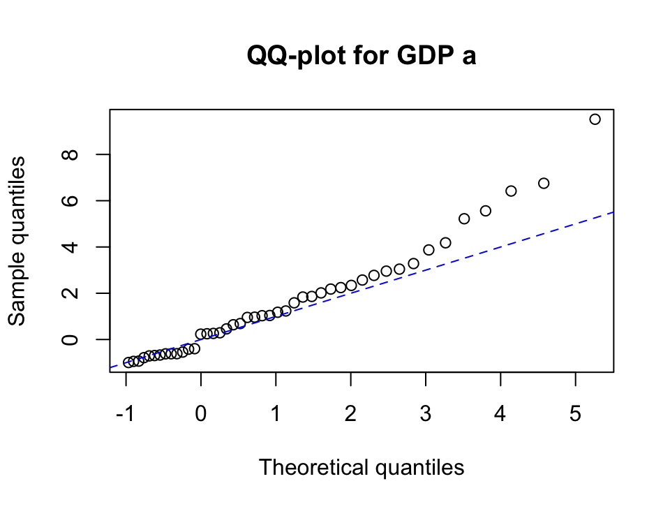

(a) QQ-plot for GDP a

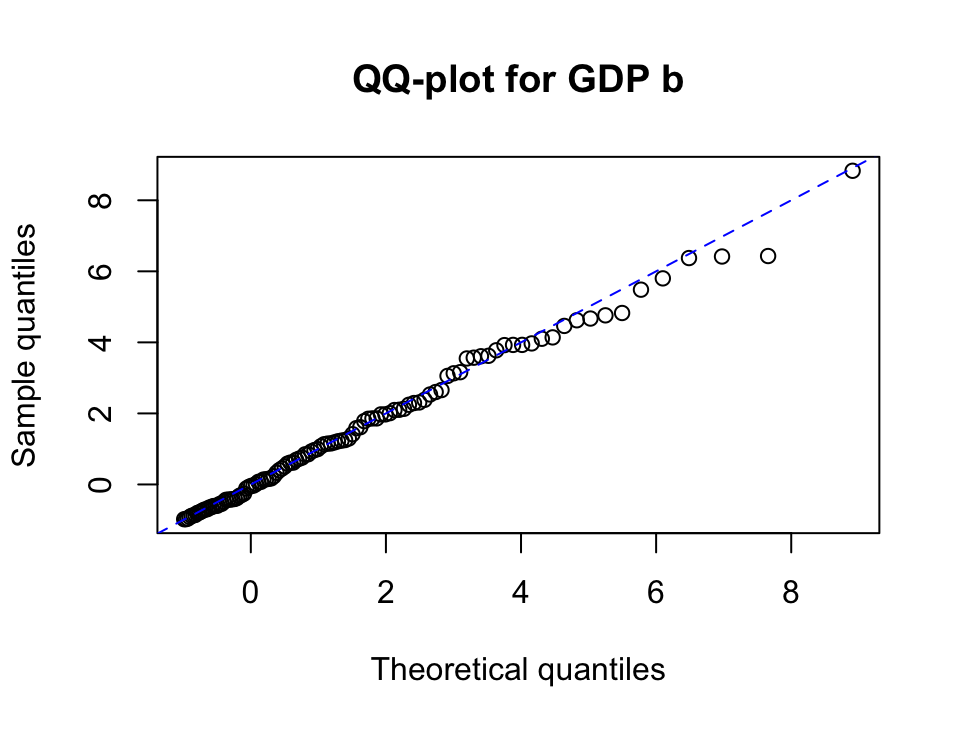

(b) QQ-plot for GDP b

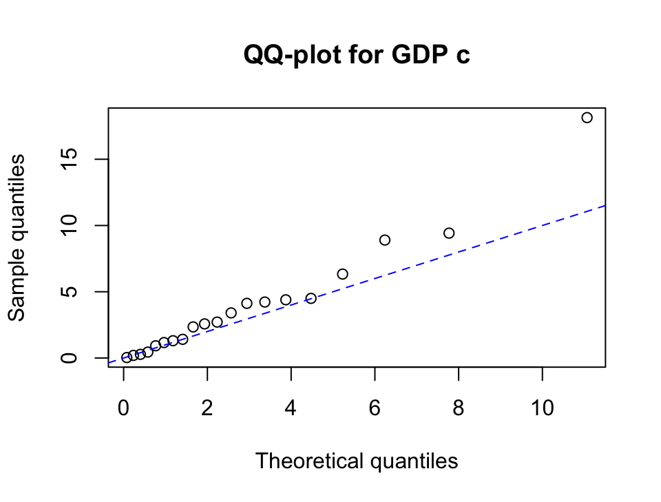

(c) QQ-plot for GDP c

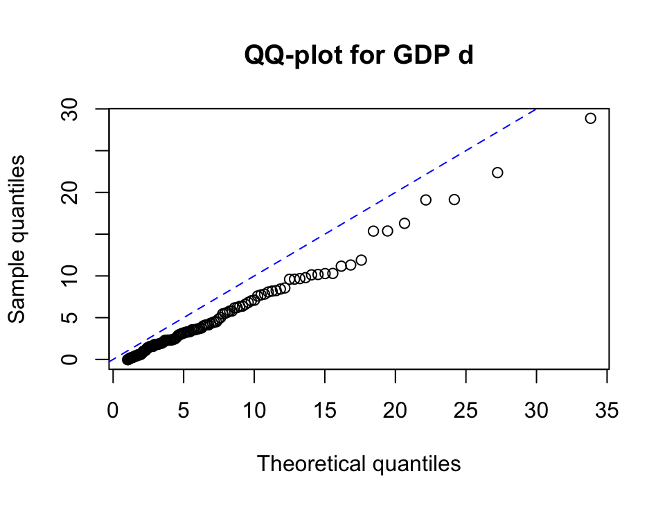

(d) QQ-plot for GDP d

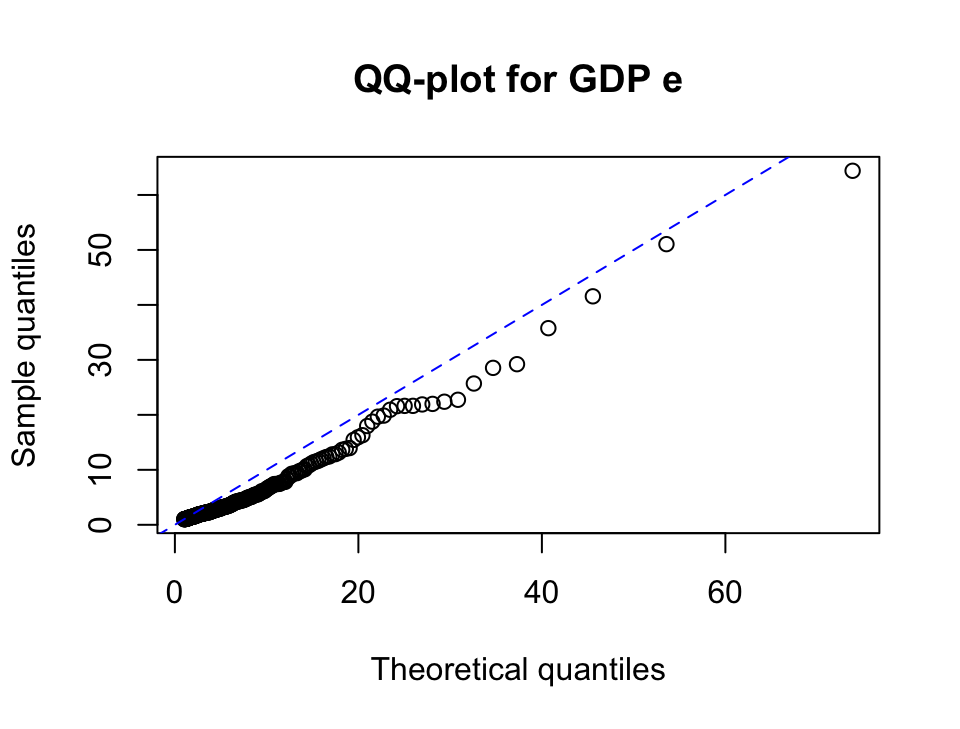

(e) QQ-plot for GDP e

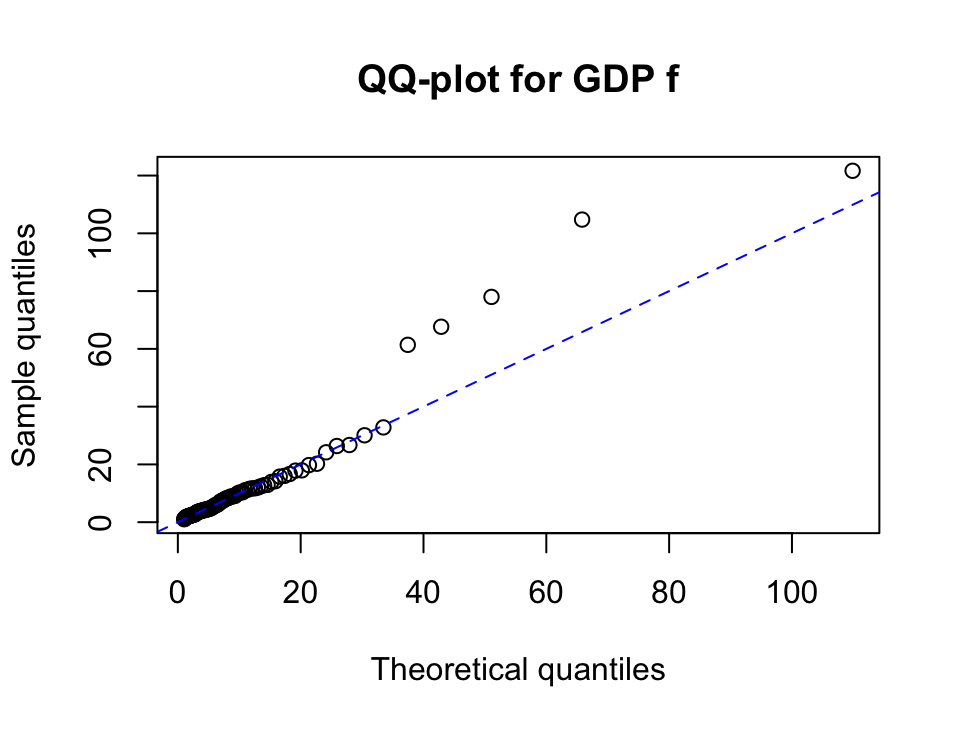

(f) QQ-plot for GDP f

Figure 1: QQ-plots comparing the observed and theoretical quantiles of the recorded GPD.

Figure 1 suggests that samples $\textbf{a}$ and $\textbf{d}$ are inconsistent with their recorded parameters. For sample $\textbf{a}$, the points in the upper tail of Figure 1 (a) drifts away from the blue dashed reference line $y=x$. Also, since its recorded shape parameter is $\xi=-0.4 < 0$, the distribution must has finite upper endpoint $x^+=u-\sigma/\xi=6.5$, but the sample clearly contains an observation greater than $8$. Therefore, there are some strong evidences that suggests the parameters recorded for sample $\textbf{a}$ are incorrect. That aside, in Figure 1 (d), qq-plot for sample $\textbf{d}$ are completely below the reference line, which indicates that its recorded parameters are incorrect.

In contrast, sample $\textbf{b}$ follows the reference line closely in Figure 1 (b). Samples $\textbf{c}$, $\textbf{e}$ and $\textbf{f}$ has some deviations in their upper tails, shown on Figure 1 (c), Figure 1 (e), and Figure 1 (f), respectively, but these are weak evidence of incorrect parameters. Sample $\textbf{c}$ only has 20 observations, which is insufficient to deduce a significant conclusion. Samples $\textbf{e}$ and $\textbf{f}$ both have recorded $\xi >0$ and hence a heavy upper tail fits with the plots. Overall, I would strongly suggest to only identify $\textbf{a}$ and $\textbf{d}$ as the incorrectly recorded parameter sets, and weakly suspect $\textbf{c}$, $\textbf{e}$ and $\textbf{f}$.

### Question 4

*For this question, all R code should be displayed only within the appendix, not in the main report.*

A hydrologist is interested in understanding the river flow at a location that is historically prone to flooding. There is a river flow gauge nearby which measures river flow in units of cubic meters per second ($\text{m}^3/\text{s}$ or cumecs). Based on her knowledge of other rivers, the hydrologist proposes that for this river gauge:

- the distribution of river flow values is constant over time
- for river flows exceeding 75 cumecs, it is appropriate to model these data as independent and identically distributed GPD($\sigma =29.7$, $\xi=0.62$, $u = 0$).

Use `riverflow_2015-2024.csv` to conduct an exploratory investigation of whether these proposals are valid for the dataset provided. Summarise your findings in 250-350 words, supporting these with a collection of 4 visualisations/figures.

**TipSet yourself up for success**

Does your answer contain:

- 400-500 words of text clearly describing your choice of visualisations, their interpretation and your conclusions about the validity of each assumption,
- A series of 4 visualisations / figures,
- A varied and appropriate choice of figures to investigate each of the hydrologist’s proposals,
- Figures with clear text, useful captions and appropriate visual mapping of data;
- At least one reference to each visualisation within the main text.

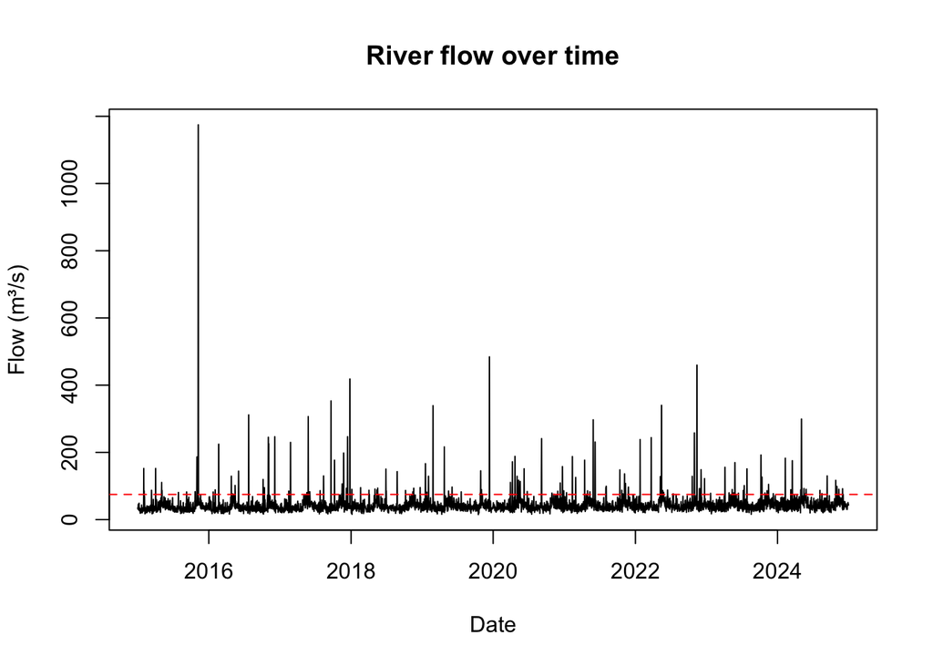

Figure 2: Time series plot for daily river flow from 2015 to 2024.

Figure 2 displays the daily river flow against time from 2015 to 2024. A time-series plot was chosen as the initial visualisation because it shows a rough overview of the observations. The 75 cumecs threshold is shown by the dashed red line, which identified the time and magnitude of flow exceeded. These extreme observations stretch the vertical scale and consequently compress the majority of river flow observations near the bottom of the figure. As a result, the plot provides a useful overview of the complete dataset, but changes in the flow distribution are difficult to assess from this figure.

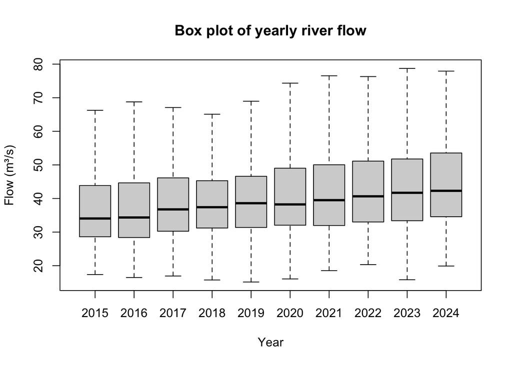

Figure 3: Box plot for yearly river flow from 2015 to 2024.

Figure 3 shows yearly box plots which checks changes in the distribution of river flow more clearly. This visualisation was chosen because the extreme observations seen in Figure 2 compress most of the data, causing changes in typical river flow difficult to identify, so we used box plots to summarise the full data within each year. There is a clear overall upward trend in the distributions over the years, with both the medians and quartiles generally increasing over time. This trend suggests that the distribution of river flow is not constant over time, providing evidence against the first assumption.

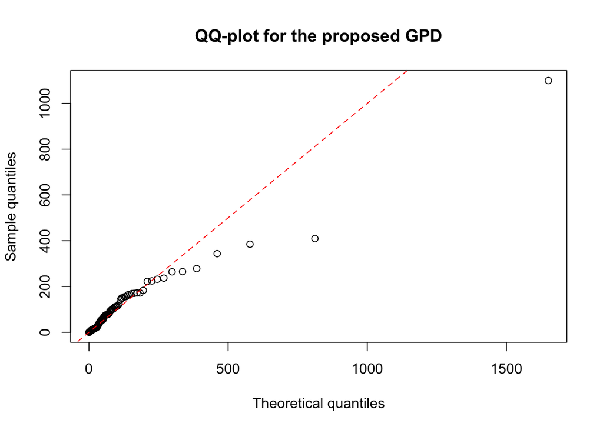

Figure 4: QQ-plot of observed against theoretical quantiles from the proposed GPD.

Figure 4 shows a qq-plot to investigate whether river flows exceeding 75 cumecs are consistent with the proposed GPD.This was chosen because it compares the observed exceedance quantiles with those expected under the proposed distribution; a good fit would have all points close to the red dashed $y=x$ reference line. The points follow the reference line reasonably closely for the lower and middle quantiles, but increasingly deviate from it in the upper tail, where the theoretical quantiles tend to exceed the observed quantiles. This indicates that the proposed GPD provides a reasonable approximation for most exceedances, but its fit is less so for the most extreme values.

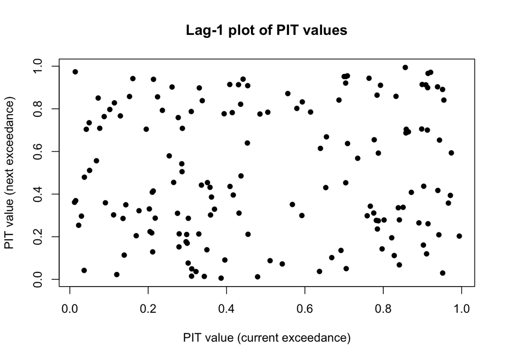

Figure 5: Lag-1 plot of probability integral transformed river flow exceedances.

Figure 5 investigates the independence assumption for the river flow exceedances using the probability integral transform (PIT) from the background material. Each exceedance was transformed, if the proposed marginal distribution is appropriate, the transformed values should follow a $U[0,1]$ distribution; if the exceedances are also independent, successive transformed values should not show pattern. Therefore, here we compare each PIT value with the value corresponding to the next exceedance, the points are spread across the unit square without any clear pattern. There is no visual evidence of dependence between consecutive exceedances, which consistent with the independence assumption.

Overall, these exploratory investigation provides evidence against the assumption that the distribution of river flow is constant over time. For flows exceeding 75 cumecs, the proposed GPD provides a reasonable description of the majority of sample points, but the qq-plot indicates clear deviation in the upper tail. The lag-1 plot also show no obvious pattern, so no evidence against the iid assumption. Therefore, the first assumption does not appear valid, but the second assumption is broadly reasonable.

**TipSet yourself up for success**

- Does your document render without any formatting issues?

## Question 5 Reflective Summary

Describe, evidence and reflect on the process of constructing the visualisations in your answer to Question 4.

Your response should be 300-400 words and might, for example, comment on:

- why you chose these forms of visualisation and what alternatives you considered;
- a challenge you faced or something that you learned while making the visualisations;
- how you might approach this task differently with more time or for a different intended audience.

**TipSet yourself up for success**

Does your response:

- describe how you engaged with the visualisation activity;
- give specific evidence of that engagement;
- critically reflection on that engagement?

When constructing the visualisations for Question 4, I initially focused on displaying an rough overview of the river flow data directly. I began with a time-series plot (see Figure 2 in Question 4). However, I found that in this plot, changes in typical river flow difficult to see. I kept these extreme observations because I think they were an important part of the data and useful for the purpose to give an overview of the data. I then plotted yearly box plots (see Figure 3 in Question 4), which made the gradual upward shift in the distribution of flow much clearer. This made me realise that displaying all individual points is sensible for a rough overview but could be quite messy and cannot see details, sometimes we could group the data for clearer trend. Using multiple visualisations allowed me to examine different features of the data that could not be assessed from a single plot (Shatz 2024).

For the proposed GPD, I chose a qq-plot (see Figure 4 in Question 4) because it’s useful to identify whether the distribution matched with the data. An important step was recognising that I needed to have the exceedances above the threshold as, $X-75$, not the original river flows, to be consistent with the use of the GPD for modelling exceedances (Risser and Tebaldi 2025). Although most points were reasonably close to the reference line, the largest observations showed greater deviations, making me the question the stability in the upper tail.

I found investigating the iid assumption more challenging because independence cannot be assessed directly from the marginal distribution of the exceedances. I initially considered plotting the exceedance against time (see Figure 6 in Appendix A), but realised that no obvious temporal pattern would provide limited evidence for independence. I therefore used the probability integral transform from the background material, transforming each exceedance. I then constructed a lag-1 plot of consecutive PIT values (see Figure 5 in Question 4) to look for dependence between successive exceedances.

If I repeated the task with more time, I would use more diagnostics to see why in the GPD not fit in the upper tail, and investigate dependence at additional lags, since the lag-1 plot only considers consecutive exceedances and therefore cannot show complete independence. For a non-statistical audience, I would simplify the qq-plot and PIT terminology and explain the conclusions more visually. Overall, the task changed how I think about exploratory visualisation, an effective figure should be more than simply display the data, and should be chosen according to the specific statistical assumption we are intended to investigate.

*End of Assessment.*

# Code Appendix

```r
qgpd <- function(p, u, sigma, xi){
  # Check that probabilities are between 0 and 1
  if (any(p < 0 | p > 1, na.rm = TRUE)) {
    stop("p must be between 0 and 1.")
  }

  # Check that u is a single value, not a vector
  if (length(u) != 1) {
    stop("u must be a single real value.")
  }

  # Check that sigma is a single positive value
  if (length(sigma) != 1 || sigma <= 0) {
    stop("sigma must be a single positive real value.")
  }

  # Check that xi is a single value
  if (length(xi) != 1) {
    stop("xi must be a single real value.")
  }

  # Calculate the quantiles using the inverse formula from Q1
  if (xi != 0) {
    u + sigma*((1 - p)^(-xi) - 1)/xi
  } else {
    u - sigma * log(1 - p)
  }
}
p = c(0.5, 0.75, 0.99)
x_p = qgpd(p, 1.5, 2, -0.4)

quantiles <- data.frame(p, x_p)
knitr::kable(x = round(quantiles, 2), col.names = c("$p$", "$x_p$"))
gpd_samples <- read.csv("gpd_samples.csv")
gpd_parameters <- read.csv("gpd_parameters.csv")
for (i in 1:6) {
  id <- gpd_parameters$id[i]
  sample_val <- sort(gpd_samples$value[gpd_samples$set_id == id])

  p <- ppoints(length(sample_val))
  u <- gpd_parameters$u[i]
  sigma <- gpd_parameters$sigma[i]
  xi <- gpd_parameters$xi[i]

  theoretical_val <- qgpd(p, u, sigma, xi)

  plot(theoretical_val,
       sample_val,
       xlab = "Theoretical quantiles",
       ylab = "Sample quantiles",
       main = paste("QQ-plot for GDP", id))

  abline(a = 0, b = 1, lty = 2, col = "blue")
}

riverflow <- read.csv("riverflow_2015_2024.csv")

riverflow$date <- as.Date(riverflow$date)
riverflow$year <- format(riverflow$date, "%Y")
plot(riverflow$date,
     riverflow$flow,
     type = "l",
     xlab = "Date",
     ylab = "Flow (m³/s)",
     main = "River flow over time")

abline(h = 75, lty = 2, col = "red")
boxplot(flow ~ year,
        data = riverflow,
        outline = FALSE,
        xlab = "Year",
        ylab = "Flow (m³/s)",
        main = "Box plot of yearly river flow")
exceed <- riverflow$flow[riverflow$flow > 75] - 75

p <- ppoints(length(exceed))

theoretical <- qgpd(p, u = 0, sigma = 29.7, xi = 0.62)

plot(theoretical,
     sort(exceed),
     xlab = "Theoretical quantiles",
     ylab = "Sample quantiles",
     main = "QQ-plot for the proposed GPD")

abline(a = 0, b = 1, lty = 2, col = "red")
exceedances <- riverflow$flow[riverflow$flow > 75] - 75
pit <- 1 - (1 + 0.62 * exceedances / 29.7)^(-1 / 0.62)

plot(pit[-length(pit)],
     pit[-1],
     pch = 16,
     xlab = "PIT value (current exceedance)",
     ylab = "PIT value (next exceedance)",
     main = "Lag-1 plot of PIT values")
extreme <- riverflow$flow > 75

plot(riverflow$date[extreme],
     riverflow$flow[extreme] - 75,
     pch = 16,
     xlab = "Date",
     ylab = "Exceedance (m³/s)",
     main = "River flow exceedances over time")
```

# Appendix A: Supporting evidence

This appendix provides the evidence referred to in the reflective writing example.

## A1. Flow exceedances scatter plot

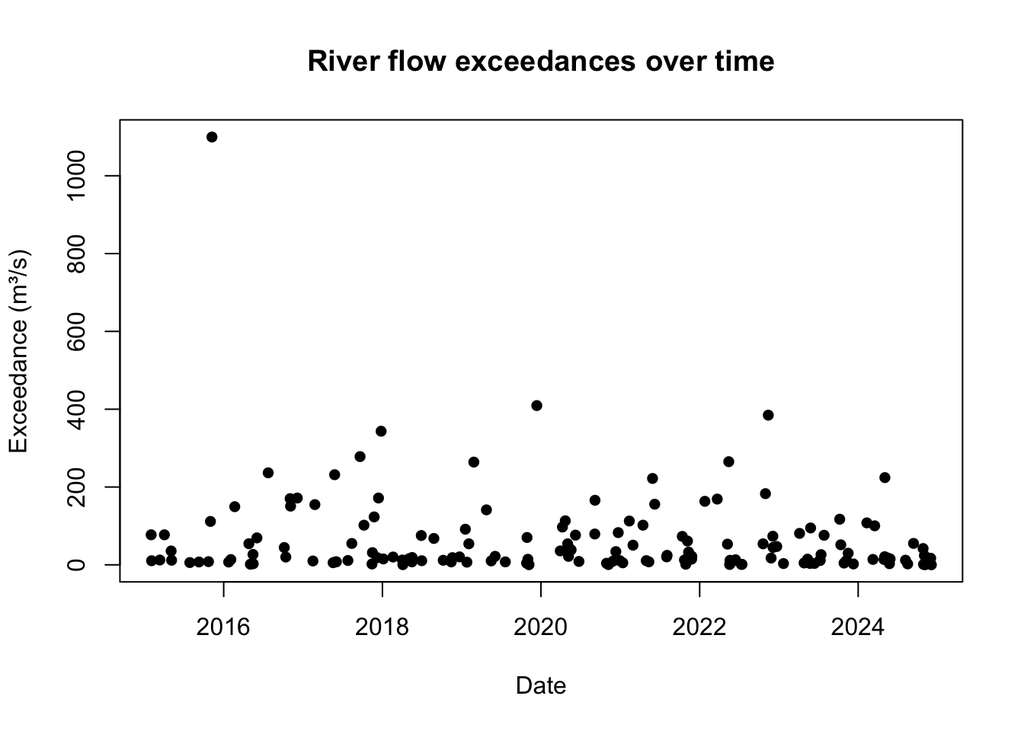

Figure 6: River flow exceedances above 75 cumecs over time.

### References

Risser, Mark D., and Claudia Tebaldi. 2025. “Uncertainty and Extremes.” In *Uncertainty in Climate Change Research: An Integrated Approach*, edited by Linda O. Mearns, Chris E. Forest, Hayley J. Fowler, Robert Lempert, and Robert L. Wilby. Springer Nature Switzerland. https://doi.org/10.1007/978-3-031-85542-9_21.

Shatz, Itamar. 2024. “Assumption-Checking Rather Than (Just) Testing: The Importance of Visualization and Effect Size in Statistical Diagnostics.” *Behavior Research Methods* 56 (2): 826–45. https://doi.org/10.3758/s13428-023-02072-x.